# I. Analiza wstępna danych

```python
import pandas as pd

gliwice = pd.read_excel("Miasta/Gliwice 24h 2007-2014.xlsx", header=3)
tychy = pd.read_excel("Miasta/Tychy 24h 2007-2014.xlsx", header=3)

print("Gliwice:")
display(gliwice.head(10))

print("Tychy:")
display(tychy.head(10))
```

```
Gliwice:
```

|  | Unnamed: 0 | NO | NO2 | NOx | PM10 | PM2.5 | SO2 | cisnienie | kier | opad_atm | predk | prom | temp | wilg |
| --- | --- | --- | --- | --- | --- | --- | --- | --- | --- | --- | --- | --- | --- | --- |
| 0 | Data | 1g | 1g | 1g | 1g | 24g | 1g | 1g | 1g | 1g | 1g | 1g | 1g | 1g |
| 1 | 2007-01-01 | NaN | 9.521739 | NaN | 14.666667 | NaN | 4 | NaN | NaN | NaN | NaN | NaN | NaN | NaN |
| 2 | 2007-01-02 | NaN | 17.347826 | NaN | 22.291667 | NaN | NaN | NaN | NaN | NaN | NaN | NaN | NaN | NaN |
| 3 | 2007-01-03 | NaN | 17.47619 | NaN | 17.217391 | NaN | 2.75 | NaN | NaN | NaN | NaN | NaN | NaN | NaN |
| 4 | 2007-01-04 | NaN | 20.047619 | NaN | 13.333333 | NaN | 10.952381 | NaN | NaN | NaN | NaN | NaN | NaN | NaN |
| 5 | 2007-01-05 | NaN | 13.565217 | NaN | 13.791667 | NaN | 3.26087 | NaN | NaN | NaN | NaN | NaN | NaN | NaN |
| 6 | 2007-01-06 | NaN | 14 | NaN | 19.458333 | NaN | 3.695652 | NaN | NaN | NaN | NaN | NaN | NaN | NaN |
| 7 | 2007-01-07 | NaN | 13.086957 | NaN | 13.625 | NaN | 3.913043 | NaN | NaN | NaN | NaN | NaN | NaN | NaN |
| 8 | 2007-01-08 | NaN | 31.782609 | NaN | 35.333333 | NaN | 13.782609 | NaN | NaN | NaN | NaN | NaN | NaN | NaN |
| 9 | 2007-01-09 | NaN | 19.391304 | NaN | 23.375 | NaN | 5.434783 | NaN | NaN | NaN | NaN | NaN | NaN | NaN |

```
Tychy:
```

|  | Unnamed: 0 | NO | NO2 | NOx | O3 | PM10 | SO2 | cisnienie | kier | opad_atm | predk | prom | temp | wilg |
| --- | --- | --- | --- | --- | --- | --- | --- | --- | --- | --- | --- | --- | --- | --- |
| 0 | Data | 1g | 1g | 1g | 1g | 1g | 1g | 1g | 1g | 1g | 1g | 1g | 1g | 1g |
| 1 | 2007-01-01 | NaN | 11.217391 | NaN | 50.416667 | 10.125 | 9.608696 | NaN | NaN | NaN | NaN | NaN | NaN | NaN |
| 2 | 2007-01-02 | NaN | 17.956522 | NaN | 42.652174 | 17.291667 | 9.869565 | NaN | NaN | NaN | NaN | NaN | NaN | NaN |
| 3 | 2007-01-03 | NaN | 17.652174 | NaN | 33.608696 | 18.583333 | 8.782609 | NaN | NaN | NaN | NaN | NaN | NaN | NaN |
| 4 | 2007-01-04 | NaN | 11.956522 | NaN | 44.782609 | 8.333333 | 8.173913 | NaN | NaN | NaN | NaN | NaN | NaN | NaN |
| 5 | 2007-01-05 | NaN | 18.086957 | NaN | 38.73913 | 17.625 | 13.826087 | NaN | NaN | NaN | NaN | NaN | NaN | NaN |
| 6 | 2007-01-06 | NaN | 17.73913 | NaN | 32.391304 | 13.916667 | 18.73913 | NaN | NaN | NaN | NaN | NaN | NaN | NaN |
| 7 | 2007-01-07 | NaN | 12.304348 | NaN | 43.913043 | 10.791667 | 11.217391 | NaN | NaN | NaN | NaN | NaN | NaN | NaN |
| 8 | 2007-01-08 | NaN | 27.043478 | NaN | 27 | 39.458333 | 23.608696 | NaN | NaN | NaN | NaN | NaN | NaN | NaN |
| 9 | 2007-01-09 | NaN | 13.857143 | NaN | 31.590909 | 16.125 | 6.047619 | NaN | NaN | NaN | NaN | NaN | NaN | NaN |

```python
gliwice = gliwice.rename(columns={"Unnamed: 0": "Data"})
tychy = tychy.rename(columns={"Unnamed: 0": "Data"})

gliwice = gliwice[gliwice["Data"] != "Data"].copy()
tychy = tychy[tychy["Data"] != "Data"].copy()

gliwice["Data"] = pd.to_datetime(gliwice["Data"], errors="coerce")
tychy["Data"] = pd.to_datetime(tychy["Data"], errors="coerce")

display(gliwice[["Data", "PM10"]].head())
display(tychy[["Data", "PM10"]].head())
```

|  | Data | PM10 |
| --- | --- | --- |
| 1 | 2007-01-01 | 14.666667 |
| 2 | 2007-01-02 | 22.291667 |
| 3 | 2007-01-03 | 17.217391 |
| 4 | 2007-01-04 | 13.333333 |
| 5 | 2007-01-05 | 13.791667 |

|  | Data | PM10 |
| --- | --- | --- |
| 1 | 2007-01-01 | 10.125 |
| 2 | 2007-01-02 | 17.291667 |
| 3 | 2007-01-03 | 18.583333 |
| 4 | 2007-01-04 | 8.333333 |
| 5 | 2007-01-05 | 17.625 |

```python
print(gliwice.columns.tolist())
print(tychy.columns.tolist())
```

```
['Data', 'NO', 'NO2', 'NOx', 'PM10', 'PM2.5', 'SO2', 'cisnienie', 'kier', 'opad_atm', 'predk', 'prom', 'temp', 'wilg']
['Data', 'NO', 'NO2', 'NOx', 'O3', 'PM10', 'SO2', 'cisnienie', 'kier', 'opad_atm', 'predk', 'prom', 'temp', 'wilg']
```

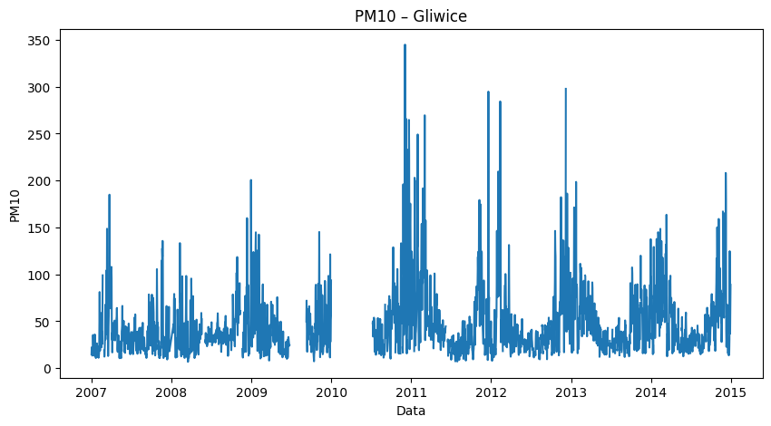

```python
import matplotlib.pyplot as plt

plt.figure(figsize=(10,5))
plt.plot(gliwice["Data"], gliwice["PM10"])
plt.title("PM10 – Gliwice")
plt.xlabel("Data")
plt.ylabel("PM10")
plt.show()
```

```python
gliwice = gliwice[["Data", "PM10"]].copy()
tychy = tychy[["Data", "PM10"]].copy()
print("Braki Gliwice:")
print(gliwice.isna().sum())

print("\nBraki Tychy:")
print(tychy.isna().sum())
```

```
Braki Gliwice:
Data      0
PM10    366
dtype: int64

Braki Tychy:
Data      0
PM10    214
dtype: int64
```

```python
gliwice["Rok"] = gliwice["Data"].dt.year
gliwice["Miesiac"] = gliwice["Data"].dt.month

tychy["Rok"] = tychy["Data"].dt.year
tychy["Miesiac"] = tychy["Data"].dt.month

gliwice_month = gliwice.groupby(["Rok", "Miesiac"])["PM10"].mean().reset_index()
tychy_month = tychy.groupby(["Rok", "Miesiac"])["PM10"].mean().reset_index()

print(gliwice_month.head())
print(tychy_month.head())
```

```
    Rok  Miesiac       PM10
0  2007        1  19.187994
1  2007        2   38.27927
2  2007        3  62.601449
3  2007        4  44.388164
4  2007        5  28.912873
    Rok  Miesiac       PM10
0  2007        1  19.922421
1  2007        2  43.105945
2  2007        3  49.478103
3  2007        4  32.577778
4  2007        5  30.971774
```

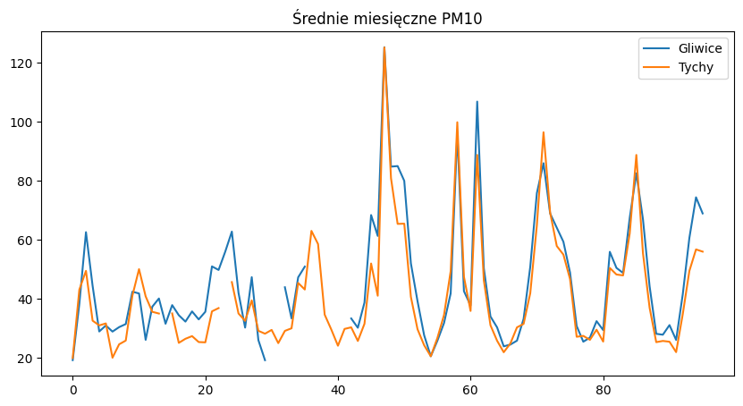

```python
import matplotlib.pyplot as plt

plt.figure(figsize=(10,5))
plt.plot(gliwice_month["PM10"], label="Gliwice")
plt.plot(tychy_month["PM10"], label="Tychy")

plt.title("Średnie miesięczne PM10")
plt.legend()
plt.show()
```

```python
import pandas as pd
import subprocess
import io

# eksport tabeli do CSV (w pamięci)
cmd = ["mdb-export", "SUM_2015-03-19.mdb", "SUM_2007_2014"]
result = subprocess.run(cmd, capture_output=True, text=True)

df = pd.read_csv(io.StringIO(result.stdout))

print(df.head())
print(df.columns)
```

```
   KOD_TERYT_PACJENTA    GMINA_PACJENTA               DATA ROZPOZNANIE  PLEC  \
0             2415041  Wodzisław Śląski  09/24/07 00:00:00         J45   1.0
1             2469011          Katowice  02/23/07 00:00:00         J45   1.0
2             2475011         Sosnowiec  07/11/07 00:00:00         J45   1.0
3             2469011          Katowice  04/24/07 00:00:00         J44   1.0
4             2469011          Katowice  07/12/07 00:00:00       J45.0   2.0

   WIEK  LB_OSOB
0  68.0        1
1  30.0        1
2  50.0        1
3  54.0        1
4  51.0        1
Index(['KOD_TERYT_PACJENTA', 'GMINA_PACJENTA', 'DATA', 'ROZPOZNANIE', 'PLEC',
       'WIEK', 'LB_OSOB'],
      dtype='str')
```

```python
# tylko J45
df_j45 = df[df["ROZPOZNANIE"].str.startswith("J45", na=False)]

# tylko Gliwice i Tychy
df_j45 = df_j45[df_j45["GMINA_PACJENTA"].isin(["Gliwice", "Tychy"])]

print(df_j45.head())
```

```
    KOD_TERYT_PACJENTA GMINA_PACJENTA               DATA ROZPOZNANIE  PLEC  \
8              2466011        Gliwice  11/08/07 00:00:00         J45   1.0
17             2477011          Tychy  11/30/07 00:00:00         J45   2.0
19             2477011          Tychy  04/02/07 00:00:00         J45   1.0
20             2466011        Gliwice  03/26/07 00:00:00         J45   2.0
33             2466011        Gliwice  03/30/07 00:00:00         J45   2.0

    WIEK  LB_OSOB
8    NaN        9
17  45.0        1
19  49.0        2
20  42.0        1
33  46.0        2
```

```python
df_j45["DATA"] = pd.to_datetime(df_j45["DATA"], errors="coerce")

df_j45_grouped = (
    df_j45.groupby(["DATA", "GMINA_PACJENTA"])["LB_OSOB"]
    .sum()
    .reset_index()
)

df_j45_grouped = df_j45_grouped.rename(columns={
    "DATA": "Data",
    "GMINA_PACJENTA": "Miasto",
    "LB_OSOB": "J45"
})

print(df_j45_grouped.head(10))
```

```
        Data   Miasto  J45
0 2007-01-01  Gliwice    2
1 2007-01-02  Gliwice   82
2 2007-01-02    Tychy   61
3 2007-01-03  Gliwice  104
4 2007-01-03    Tychy   57
5 2007-01-04  Gliwice   70
6 2007-01-04    Tychy   65
7 2007-01-05  Gliwice   90
8 2007-01-05    Tychy   65
9 2007-01-06  Gliwice    2
```

```python
# Utworzenie finalnego dataset

# przygotowanie J45 do miesięcy
df_j45_grouped["Rok"] = df_j45_grouped["Data"].dt.year
df_j45_grouped["Miesiac"] = df_j45_grouped["Data"].dt.month

j45_month = (
    df_j45_grouped
    .groupby(["Rok", "Miesiac", "Miasto"])["J45"]
    .sum()
    .reset_index()
)

print(j45_month.head())

# dodanie miasta do PM10
gliwice_month["Miasto"] = "Gliwice"
tychy_month["Miasto"] = "Tychy"

# połączenie wszystkiego
pm10_all = pd.concat([gliwice_month, tychy_month])

df_all = pd.merge(
    pm10_all,
    j45_month,
    on=["Rok", "Miesiac", "Miasto"],
    how="inner"
)

print(df_all.head(10))
```

```
    Rok  Miesiac   Miasto   J45
0  2007        1  Gliwice  1941
1  2007        1    Tychy  1428
2  2007        2  Gliwice  1707
3  2007        2    Tychy  1144
4  2007        3  Gliwice  2031
    Rok  Miesiac       PM10   Miasto   J45
0  2007        1  19.187994  Gliwice  1941
1  2007        2   38.27927  Gliwice  1707
2  2007        3  62.601449  Gliwice  2031
3  2007        4  44.388164  Gliwice  1829
4  2007        5  28.912873  Gliwice  1810
5  2007        6    30.9375  Gliwice  1726
6  2007        7  28.869331  Gliwice  1403
7  2007        8  30.387915  Gliwice  1235
8  2007        9  31.425928  Gliwice  1618
9  2007       10   42.40159  Gliwice  1784
```

```python
# Analiza braków danych i przygotowanie zbioru do dalszych obliczeń

# upewniamy się, że badane cechy są liczbami
df_all["PM10"] = pd.to_numeric(df_all["PM10"], errors="coerce")
df_all["J45"] = pd.to_numeric(df_all["J45"], errors="coerce")

# utworzenie daty miesięcznej
df_all["Data"] = pd.to_datetime(
    df_all["Rok"].astype(str) + "-" + df_all["Miesiac"].astype(str) + "-01"
)

print("Braki danych w df_all:")
print(df_all.isna().sum())

print("\nProcent braków danych w df_all:")
print((df_all.isna().mean() * 100).round(2))

# usuwamy obserwacje z brakującymi wartościami PM10 lub J45
df_clean = df_all.dropna(subset=["PM10", "J45"]).copy()

print("\nLiczba wierszy przed usunięciem braków:", df_all.shape[0])
print("Liczba wierszy po usunięciu braków:", df_clean.shape[0])
print("Liczba usuniętych wierszy:", df_all.shape[0] - df_clean.shape[0])

display(df_clean.head())
```

```
Braki danych w df_all:
Rok         0
Miesiac     0
PM10       10
Miasto      0
J45         0
Data        0
dtype: int64

Procent braków danych w df_all:
Rok        0.00
Miesiac    0.00
PM10       5.21
Miasto     0.00
J45        0.00
Data       0.00
dtype: float64

Liczba wierszy przed usunięciem braków: 192
Liczba wierszy po usunięciu braków: 182
Liczba usuniętych wierszy: 10
```

|  | Rok | Miesiac | PM10 | Miasto | J45 | Data |
| --- | --- | --- | --- | --- | --- | --- |
| 0 | 2007 | 1 | 19.187994 | Gliwice | 1941 | 2007-01-01 |
| 1 | 2007 | 2 | 38.279270 | Gliwice | 1707 | 2007-02-01 |
| 2 | 2007 | 3 | 62.601449 | Gliwice | 2031 | 2007-03-01 |
| 3 | 2007 | 4 | 44.388164 | Gliwice | 1829 | 2007-04-01 |
| 4 | 2007 | 5 | 28.912873 | Gliwice | 1810 | 2007-05-01 |

```python
# Podstawowe statystyki dla dwóch badanych cech
statystyki = df_clean[["PM10", "J45"]].describe()

display(statystyki)
def punkt_srodkowy(series):
    return (series.min() + series.max()) / 2

podsumowanie = pd.DataFrame({
    "Średnia": [df_clean["PM10"].mean(), df_clean["J45"].mean()],
    "Mediana": [df_clean["PM10"].median(), df_clean["J45"].median()],
    "Punkt środkowy": [punkt_srodkowy(df_clean["PM10"]), punkt_srodkowy(df_clean["J45"])],
    "Minimum": [df_clean["PM10"].min(), df_clean["J45"].min()],
    "Maksimum": [df_clean["PM10"].max(), df_clean["J45"].max()],
    "Odchylenie standardowe": [df_clean["PM10"].std(), df_clean["J45"].std()]
}, index=["PM10", "J45"])

display(podsumowanie)
```

|  | PM10 | J45 |
| --- | --- | --- |
| count | 182.000000 | 182.000000 |
| mean | 43.281112 | 1401.263736 |
| std | 20.181264 | 271.296777 |
| min | 19.170057 | 645.000000 |
| 25% | 29.200075 | 1223.000000 |
| 50% | 36.358458 | 1402.500000 |
| 75% | 50.739338 | 1592.500000 |
| max | 125.336831 | 2031.000000 |

|  | Średnia | Mediana | Punkt środkowy | Minimum | Maksimum | Odchylenie standardowe |
| --- | --- | --- | --- | --- | --- | --- |
| PM10 | 43.281112 | 36.358458 | 72.253444 | 19.170057 | 125.336831 | 20.181264 |
| J45 | 1401.263736 | 1402.500000 | 1338.000000 | 645.000000 | 2031.000000 | 271.296777 |

```python
# Statystyki z podziałem na miasta
statystyki_miasta = df_clean.groupby("Miasto")[["PM10", "J45"]].agg(
    ["count", "mean", "median", "min", "max", "std"]
)

display(statystyki_miasta)
```

| Miasto | PM10 count | PM10 mean | PM10 median | PM10 min | PM10 max | PM10 std | J45 count | J45 mean | J45 median | J45 min | J45 max | J45 std |
| --- | --- | --- | --- | --- | --- | --- | --- | --- | --- | --- | --- | --- |
| Gliwice | 88 | 45.77362 | 39.654329 | 19.170057 | 125.336831 | 20.821409 | 88 | 1563.681818 | 1582.5 | 985 | 2031 | 229.380953 |
| Tychy | 94 | 40.94770 | 34.886769 | 19.922421 | 125.251120 | 19.383669 | 94 | 1249.212766 | 1284.5 | 645 | 1730 | 213.766825 |

```python
# Wykres słupkowy średnich wartości
mean_values = df_clean.groupby("Miasto")[["PM10", "J45"]].mean()

display(mean_values)
```

| Miasto | PM10 | J45 |
| --- | --- | --- |
| Gliwice | 45.77362 | 1563.681818 |
| Tychy | 40.94770 | 1249.212766 |

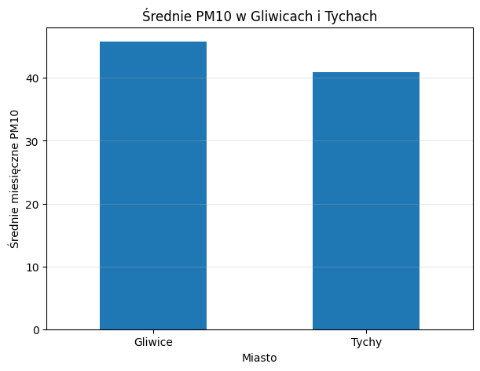

```python
# PM10
plt.figure(figsize=(7, 5))
mean_values["PM10"].plot(kind="bar")
plt.title("Średnie PM10 w Gliwicach i Tychach")
plt.xlabel("Miasto")
plt.ylabel("Średnie miesięczne PM10")
plt.xticks(rotation=0)
plt.grid(axis="y", alpha=0.3)
plt.show()
```

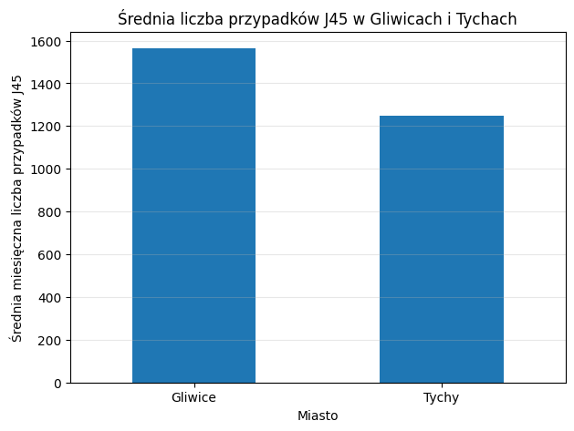

```python
# J45
plt.figure(figsize=(7, 5))
mean_values["J45"].plot(kind="bar")
plt.title("Średnia liczba przypadków J45 w Gliwicach i Tychach")
plt.xlabel("Miasto")
plt.ylabel("Średnia miesięczna liczba przypadków J45")
plt.xticks(rotation=0)
plt.grid(axis="y", alpha=0.3)
plt.show()
```

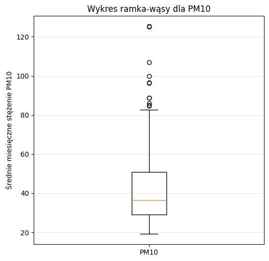

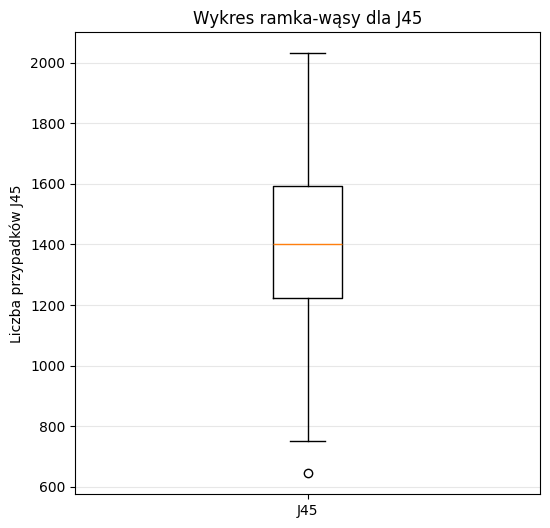

```python
import matplotlib.pyplot as plt

# upewniamy się, że PM10 i J45 są liczbami i nie mają braków
pm10_values = df_clean["PM10"].dropna()
j45_values = df_clean["J45"].dropna()

plt.figure(figsize=(6, 6))
plt.boxplot(pm10_values, vert=True, labels=["PM10"])
plt.title("Wykres ramka-wąsy dla PM10")
plt.ylabel("Średnie miesięczne stężenie PM10")
plt.grid(axis="y", alpha=0.3)
plt.show()

plt.figure(figsize=(6, 6))
plt.boxplot(j45_values, vert=True, labels=["J45"])
plt.title("Wykres ramka-wąsy dla J45")
plt.ylabel("Liczba przypadków J45")
plt.grid(axis="y", alpha=0.3)
plt.show()
```

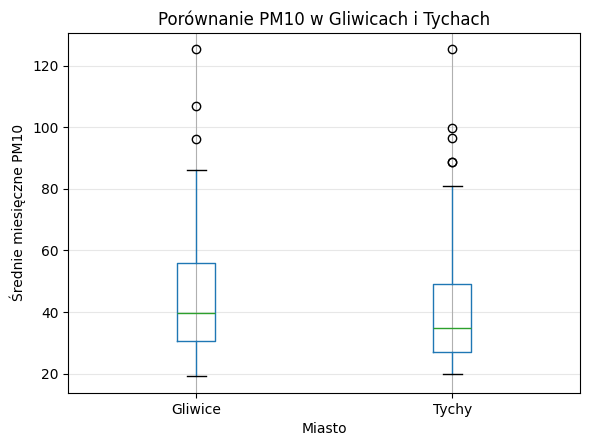

```python
# Boxplot z podziałem na miasta
plt.figure(figsize=(8, 6))
df_clean.boxplot(column="PM10", by="Miasto")
plt.title("Porównanie PM10 w Gliwicach i Tychach")
plt.suptitle("")
plt.xlabel("Miasto")
plt.ylabel("Średnie miesięczne PM10")
plt.grid(axis="y", alpha=0.3)
plt.show()
```

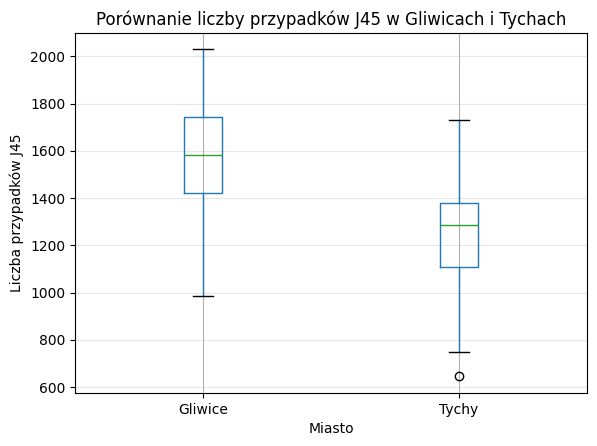

```python
# Dla J45
plt.figure(figsize=(8, 6))
df_clean.boxplot(column="J45", by="Miasto")
plt.title("Porównanie liczby przypadków J45 w Gliwicach i Tychach")
plt.suptitle("")
plt.xlabel("Miasto")
plt.ylabel("Liczba przypadków J45")
plt.grid(axis="y", alpha=0.3)
plt.show()
```

```python
# Outliery dla PM10 i J45
def znajdz_outliery_iqr(df, column):
    Q1 = df[column].quantile(0.25)
    Q3 = df[column].quantile(0.75)
    IQR = Q3 - Q1

    dolna_granica = Q1 - 1.5 * IQR
    gorna_granica = Q3 + 1.5 * IQR

    outliers = df[(df[column] < dolna_granica) | (df[column] > gorna_granica)]

    print(f"Zmienna: {column}")
    print("Q1:", Q1)
    print("Q3:", Q3)
    print("IQR:", IQR)
    print("Dolna granica:", dolna_granica)
    print("Górna granica:", gorna_granica)
    print("Liczba outlierów:", len(outliers))

    return outliers

outliers_pm10 = znajdz_outliery_iqr(df_clean, "PM10")
display(outliers_pm10)

outliers_j45 = znajdz_outliery_iqr(df_clean, "J45")
display(outliers_j45)
```

```
Zmienna: PM10
Q1: 29.2000749518027
Q3: 50.73933836647586
IQR: 21.53926341467316
Dolna granica: -3.108820170207043
Górna granica: 83.04823348848561
Liczba outlierów: 11
```

|  | Rok | Miesiac | PM10 | Miasto | J45 | Data |
| --- | --- | --- | --- | --- | --- | --- |
| 47 | 2010 | 12 | 125.336831 | Gliwice | 1457 | 2010-12-01 |
| 48 | 2011 | 1 | 84.818579 | Gliwice | 1580 | 2011-01-01 |
| 49 | 2011 | 2 | 85.020880 | Gliwice | 1585 | 2011-02-01 |
| 58 | 2011 | 11 | 96.300522 | Gliwice | 1882 | 2011-11-01 |
| 61 | 2012 | 2 | 106.891304 | Gliwice | 1549 | 2012-02-01 |
| 71 | 2012 | 12 | 86.001651 | Gliwice | 1154 | 2012-12-01 |
| 143 | 2010 | 12 | 125.251120 | Tychy | 1312 | 2010-12-01 |
| 154 | 2011 | 11 | 99.882126 | Tychy | 1532 | 2011-11-01 |
| 157 | 2012 | 2 | 88.788793 | Tychy | 1418 | 2012-02-01 |
| 167 | 2012 | 12 | 96.485215 | Tychy | 753 | 2012-12-01 |
| 181 | 2014 | 2 | 88.791667 | Tychy | 1375 | 2014-02-01 |

```
Zmienna: J45
Q1: 1223.0
Q3: 1592.5
IQR: 369.5
Dolna granica: 668.75
Górna granica: 2146.75
Liczba outlierów: 1
```

|  | Rok | Miesiac | PM10 | Miasto | J45 | Data |
| --- | --- | --- | --- | --- | --- | --- |
| 179 | 2013 | 12 | 47.929874 | Tychy | 645 | 2013-12-01 |

```python
# Sprawdzenie wpływu outlierów na średnią
# PM10 bez outlierów
Q1_pm10 = df_clean["PM10"].quantile(0.25)
Q3_pm10 = df_clean["PM10"].quantile(0.75)
IQR_pm10 = Q3_pm10 - Q1_pm10

df_pm10_no_outliers = df_clean[
    (df_clean["PM10"] >= Q1_pm10 - 1.5 * IQR_pm10) &
    (df_clean["PM10"] <= Q3_pm10 + 1.5 * IQR_pm10)
]

print("PM10 - średnia z outlierami:", df_clean["PM10"].mean())
print("PM10 - średnia bez outlierów:", df_pm10_no_outliers["PM10"].mean())

print("PM10 - mediana z outlierami:", df_clean["PM10"].median())
print("PM10 - mediana bez outlierów:", df_pm10_no_outliers["PM10"].median())
```

```
PM10 - średnia z outlierami: 43.281111802604805
PM10 - średnia bez outlierów: 39.72861789969217
PM10 - mediana z outlierami: 36.35845772400461
PM10 - mediana bez outlierów: 35.0333333334
```

# II. Testy parametryczne i nieparametryczne

```python
# Przygotowanie danych do testów statystycznych

from scipy.stats import shapiro, ttest_ind, mannwhitneyu, ttest_rel, wilcoxon, chisquare
import scipy.stats as st
import numpy as np
import pandas as pd
import matplotlib.pyplot as plt

# Podział danych na miasta
gliwice_data = df_clean[df_clean["Miasto"] == "Gliwice"].copy()
tychy_data = df_clean[df_clean["Miasto"] == "Tychy"].copy()

# Zmienne do testów
gliwice_pm10 = gliwice_data["PM10"].dropna()
tychy_pm10 = tychy_data["PM10"].dropna()

gliwice_j45 = gliwice_data["J45"].dropna()
tychy_j45 = tychy_data["J45"].dropna()

print("Liczba obserwacji PM10 - Gliwice:", len(gliwice_pm10))
print("Liczba obserwacji PM10 - Tychy:", len(tychy_pm10))
print("Liczba obserwacji J45 - Gliwice:", len(gliwice_j45))
print("Liczba obserwacji J45 - Tychy:", len(tychy_j45))
```

```
Liczba obserwacji PM10 - Gliwice: 88
Liczba obserwacji PM10 - Tychy: 94
Liczba obserwacji J45 - Gliwice: 88
Liczba obserwacji J45 - Tychy: 94
```

```python
# Test normalności Shapiro-Wilka
# H0: badana zmienna ma rozkład normalny.
# H1: badana zmienna nie ma rozkładu normalnego.

# Jeżeli p-value > 0,05, nie ma podstaw do odrzucenia H0.
# Jeżeli p-value ≤ 0,05, odrzucamy H0 i uznajemy, że rozkład odbiega od normalnego.
alpha = 0.05

variables = {
    "PM10 Gliwice": gliwice_pm10,
    "PM10 Tychy": tychy_pm10,
    "J45 Gliwice": gliwice_j45,
    "J45 Tychy": tychy_j45
}

for name, data in variables.items():
    stat, p = shapiro(data)
    print(f"{name}: statystyka = {stat:.4f}, p-value = {p:.4f}")

    if p > alpha:
        print("Brak podstaw do odrzucenia H0 - rozkład można uznać za zbliżony do normalnego.\n")
    else:
        print("Odrzucamy H0 - rozkład istotnie odbiega od normalnego.\n")
```

```
PM10 Gliwice: statystyka = 0.8797, p-value = 0.0000
Odrzucamy H0 - rozkład istotnie odbiega od normalnego.

PM10 Tychy: statystyka = 0.8183, p-value = 0.0000
Odrzucamy H0 - rozkład istotnie odbiega od normalnego.

J45 Gliwice: statystyka = 0.9833, p-value = 0.3190
Brak podstaw do odrzucenia H0 - rozkład można uznać za zbliżony do normalnego.

J45 Tychy: statystyka = 0.9822, p-value = 0.2307
Brak podstaw do odrzucenia H0 - rozkład można uznać za zbliżony do normalnego.
```

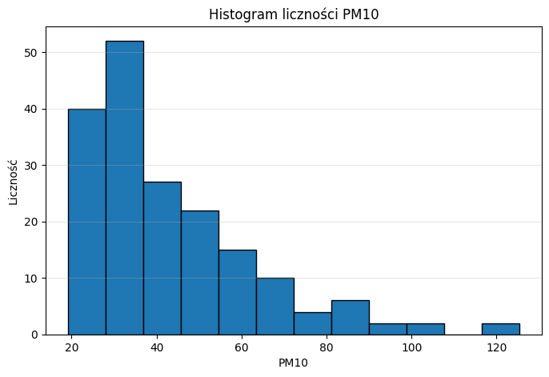

```python
# Histogram liczności PM10

plt.figure(figsize=(8, 5))
plt.hist(df_clean["PM10"], bins=12, edgecolor="black")
plt.title("Histogram liczności PM10")
plt.xlabel("PM10")
plt.ylabel("Liczność")
plt.grid(axis="y", alpha=0.3)
plt.show()
```

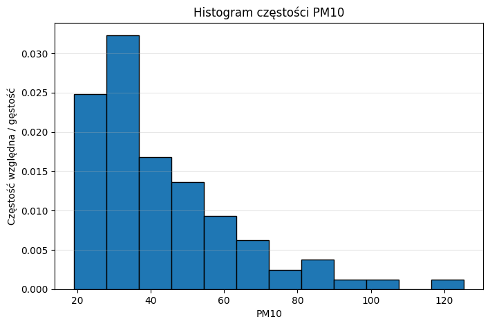

```python
# Histogram częstości PM10

plt.figure(figsize=(8, 5))
plt.hist(df_clean["PM10"], bins=12, density=True, edgecolor="black")
plt.title("Histogram częstości PM10")
plt.xlabel("PM10")
plt.ylabel("Częstość względna / gęstość")
plt.grid(axis="y", alpha=0.3)
plt.show()
```

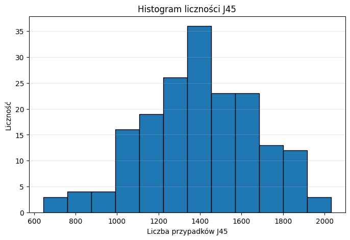

```python
# Histogram liczności J45

plt.figure(figsize=(8, 5))
plt.hist(df_clean["J45"], bins=12, edgecolor="black")
plt.title("Histogram liczności J45")
plt.xlabel("Liczba przypadków J45")
plt.ylabel("Liczność")
plt.grid(axis="y", alpha=0.3)
plt.show()
```

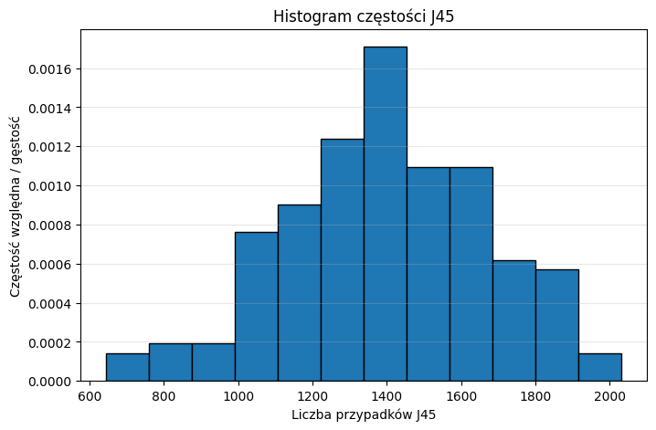

```python
# Histogram częstości J45

plt.figure(figsize=(8, 5))
plt.hist(df_clean["J45"], bins=12, density=True, edgecolor="black")
plt.title("Histogram częstości J45")
plt.xlabel("Liczba przypadków J45")
plt.ylabel("Częstość względna / gęstość")
plt.grid(axis="y", alpha=0.3)
plt.show()
```

```python
# Test Welcha dla PM10 - próby niezależne
# H0: średnie stężenie PM10 w Gliwicach i Tychach jest takie samo.
# H1: średnie stężenie PM10 w Gliwicach i Tychach różni się.

t_stat, p_value = ttest_ind(gliwice_pm10, tychy_pm10, equal_var=False)

print("Test Welcha dla PM10")
print("t-statystyka:", t_stat)
print("p-value:", p_value)

if p_value < alpha:
    print("Odrzucamy H0 - średnie PM10 w Gliwicach i Tychach różnią się istotnie.")
else:
    print("Brak podstaw do odrzucenia H0 - nie wykazano istotnej różnicy średnich PM10.")
```

```
Test Welcha dla PM10
t-statystyka: 1.6155135291442597
p-value: 0.10798406186893575
Brak podstaw do odrzucenia H0 - nie wykazano istotnej różnicy średnich PM10.
```

```python
# Test Welcha dla J45 - próby niezależne

t_stat, p_value = ttest_ind(gliwice_j45, tychy_j45, equal_var=False)

print("Test Welcha dla J45")
print("t-statystyka:", t_stat)
print("p-value:", p_value)

if p_value < alpha:
    print("Odrzucamy H0 - średnia liczba przypadków J45 różni się istotnie między miastami.")
else:
    print("Brak podstaw do odrzucenia H0 - nie wykazano istotnej różnicy średnich J45.")
```

```
Test Welcha dla J45
t-statystyka: 9.55116231990456
p-value: 1.0848752378809607e-17
Odrzucamy H0 - średnia liczba przypadków J45 różni się istotnie między miastami.
```

```python
# Test Manna-Whitneya dla PM10

stat, p_value = mannwhitneyu(gliwice_pm10, tychy_pm10, alternative="two-sided")

print("Test Manna-Whitneya dla PM10")
print("statystyka:", stat)
print("p-value:", p_value)

if p_value < alpha:
    print("Odrzucamy H0 - rozkłady PM10 w miastach różnią się istotnie.")
else:
    print("Brak podstaw do odrzucenia H0 - nie wykazano istotnej różnicy rozkładów PM10.")
```

```
Test Manna-Whitneya dla PM10
statystyka: 4858.0
p-value: 0.04221410133032418
Odrzucamy H0 - rozkłady PM10 w miastach różnią się istotnie.
```

```python
# Test Manna-Whitneya dla J45

stat, p_value = mannwhitneyu(gliwice_j45, tychy_j45, alternative="two-sided")

print("Test Manna-Whitneya dla J45")
print("statystyka:", stat)
print("p-value:", p_value)

if p_value < alpha:
    print("Odrzucamy H0 - rozkłady J45 w miastach różnią się istotnie.")
else:
    print("Brak podstaw do odrzucenia H0 - nie wykazano istotnej różnicy rozkładów J45.")
```

```
Test Manna-Whitneya dla J45
statystyka: 6962.5
p-value: 1.7661314005262001e-15
Odrzucamy H0 - rozkłady J45 w miastach różnią się istotnie.
```

```python
# Przygotowanie danych sparowanych: Gliwice vs Tychy miesiąc po miesiącu

paired_pm10 = df_clean.pivot_table(
    index=["Rok", "Miesiac"],
    columns="Miasto",
    values="PM10"
).dropna()

display(paired_pm10.head())
print(paired_pm10.shape)
```

| Rok | Miasto Miesiac | Gliwice | Tychy |
| --- | --- | --- | --- |
| 2007 | 1 | 19.187994 | 19.922421 |
|  | 2 | 38.279270 | 43.105945 |
|  | 3 | 62.601449 | 49.478103 |
|  | 4 | 44.388164 | 32.577778 |
|  | 5 | 28.912873 | 30.971774 |

```
(86, 2)
```

```python
# Test t dla prób zależnych - PM10

t_stat, p_value = ttest_rel(paired_pm10["Gliwice"], paired_pm10["Tychy"])

print("Test t dla prób zależnych PM10")
print("t-statystyka:", t_stat)
print("p-value:", p_value)

if p_value < alpha:
    print("Odrzucamy H0 - średnie PM10 różni się istotnie między miastami w tych samych miesiącach.")
else:
    print("Brak podstaw do odrzucenia H0 - nie wykazano istotnej różnicy PM10 w tych samych miesiącach.")
```

```
Test t dla prób zależnych PM10
t-statystyka: 5.941395511904486
p-value: 6.024005126282507e-08
Odrzucamy H0 - średnie PM10 różni się istotnie między miastami w tych samych miesiącach.
```

```python
# Test Wilcoxona dla prób zależnych - PM10

stat, p_value = wilcoxon(paired_pm10["Gliwice"], paired_pm10["Tychy"])

print("Test Wilcoxona dla prób zależnych PM10")
print("statystyka:", stat)
print("p-value:", p_value)

if p_value < alpha:
    print("Odrzucamy H0 - PM10 różni się istotnie między miastami w tych samych miesiącach.")
else:
    print("Brak podstaw do odrzucenia H0 - nie wykazano istotnej różnicy PM10 w tych samych miesiącach.")
```

```
Test Wilcoxona dla prób zależnych PM10
statystyka: 661.0
p-value: 1.9078070621338508e-07
Odrzucamy H0 - PM10 różni się istotnie między miastami w tych samych miesiącach.
```

```python
# To samo dla J45
paired_j45 = df_clean.pivot_table(
    index=["Rok", "Miesiac"],
    columns="Miasto",
    values="J45"
).dropna()

display(paired_j45.head())
print(paired_j45.shape)
```

| Rok | Miasto Miesiac | Gliwice | Tychy |
| --- | --- | --- | --- |
| 2007 | 1 | 1941.0 | 1428.0 |
|  | 2 | 1707.0 | 1144.0 |
|  | 3 | 2031.0 | 1269.0 |
|  | 4 | 1829.0 | 1268.0 |
|  | 5 | 1810.0 | 1180.0 |

```
(86, 2)
```

```python
# Test t dla prób zależnych - J45

t_stat, p_value = ttest_rel(paired_j45["Gliwice"], paired_j45["Tychy"])

print("Test t dla prób zależnych J45")
print("t-statystyka:", t_stat)
print("p-value:", p_value)

if p_value < alpha:
    print("Odrzucamy H0 - liczba przypadków J45 różni się istotnie między miastami w tych samych miesiącach.")
else:
    print("Brak podstaw do odrzucenia H0 - nie wykazano istotnej różnicy J45 w tych samych miesiącach.")
```

```
Test t dla prób zależnych J45
t-statystyka: 16.21649113450118
p-value: 9.543452493048383e-28
Odrzucamy H0 - liczba przypadków J45 różni się istotnie między miastami w tych samych miesiącach.
```

```python
# Test Wilcoxona dla prób zależnych - J45

stat, p_value = wilcoxon(paired_j45["Gliwice"], paired_j45["Tychy"])

print("Test Wilcoxona dla prób zależnych J45")
print("statystyka:", stat)
print("p-value:", p_value)

if p_value < alpha:
    print("Odrzucamy H0 - J45 różni się istotnie między miastami w tych samych miesiącach.")
else:
    print("Brak podstaw do odrzucenia H0 - nie wykazano istotnej różnicy J45 w tych samych miesiącach.")
```

```
Test Wilcoxona dla prób zależnych J45
statystyka: 4.0
p-value: 9.191519416779545e-16
Odrzucamy H0 - J45 różni się istotnie między miastami w tych samych miesiącach.
```

Test chi-kwadrat

```python
# Kategoryzacja PM10

df_clean["Kategoria_PM10"] = pd.cut(
    df_clean["PM10"],
    bins=[0, 20, 50, 100, np.inf],
    labels=["bardzo niskie", "umiarkowane", "wysokie", "bardzo wysokie"]
)

pm10_counts = df_clean["Kategoria_PM10"].value_counts().sort_index()

display(pm10_counts)
```

```
Kategoria_PM10
bardzo niskie       3
umiarkowane       129
wysokie            47
bardzo wysokie      3
Name: count, dtype: int64
```

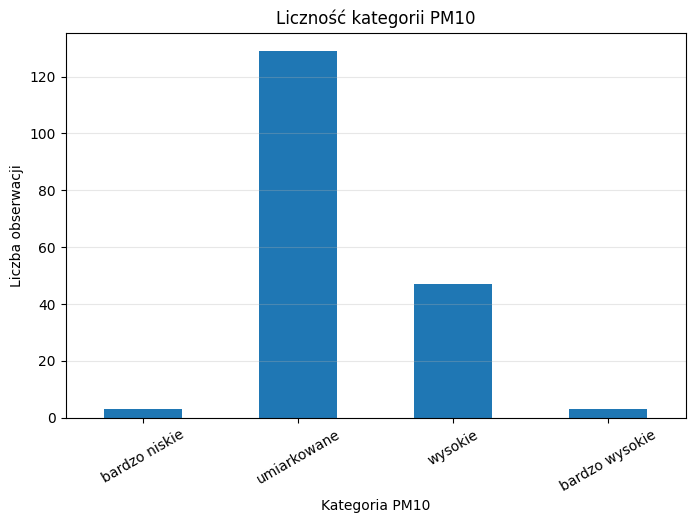

```python
plt.figure(figsize=(8, 5))
pm10_counts.plot(kind="bar")
plt.title("Liczność kategorii PM10")
plt.xlabel("Kategoria PM10")
plt.ylabel("Liczba obserwacji")
plt.xticks(rotation=30)
plt.grid(axis="y", alpha=0.3)
plt.show()
```

```python
# H0: obserwacje są równomiernie rozłożone między kategoriami PM10.
# H1: obserwacje nie są równomiernie rozłożone między kategoriami PM10.
chi_stat, p_value = chisquare(pm10_counts)

print("Test chi-kwadrat dla kategorii PM10")
print("chi2:", chi_stat)
print("p-value:", p_value)

if p_value < alpha:
    print("Odrzucamy H0 - obserwacje nie są równomiernie rozłożone między kategoriami PM10.")
else:
    print("Brak podstaw do odrzucenia H0 - nie wykazano istotnych różnic liczności między kategoriami PM10.")
```

```
Test chi-kwadrat dla kategorii PM10
chi2: 232.68131868131866
p-value: 3.6397289150909396e-50
Odrzucamy H0 - obserwacje nie są równomiernie rozłożone między kategoriami PM10.
```

```python
# 95% przedział ufności dla średniego PM10

pm10 = df_clean["PM10"].dropna()

mean_pm10 = pm10.mean()
sem_pm10 = st.sem(pm10)

ci_pm10 = st.t.interval(
    confidence=0.95,
    df=len(pm10)-1,
    loc=mean_pm10,
    scale=sem_pm10
)

print("Średnia PM10:", mean_pm10)
print("95% przedział ufności dla średniej PM10:", ci_pm10)
```

```
Średnia PM10: 43.281111802604805
95% przedział ufności dla średniej PM10: (np.float64(40.32939743459451), np.float64(46.2328261706151))
```

```python
# 95% przedział ufności dla średniej J45

j45 = df_clean["J45"].dropna()

mean_j45 = j45.mean()
sem_j45 = st.sem(j45)

ci_j45 = st.t.interval(
    confidence=0.95,
    df=len(j45)-1,
    loc=mean_j45,
    scale=sem_j45
)

print("Średnia J45:", mean_j45)
print("95% przedział ufności dla średniej J45:", ci_j45)
```

```
Średnia J45: 1401.2637362637363
95% przedział ufności dla średniej J45: (np.float64(1361.5838341699653), np.float64(1440.9436383575073))
```

# III. Korelacja i regresja

```python
# Przygotowanie danych do korelacji i regresji

corr_data = df_clean[["PM10", "J45", "Miasto", "Rok", "Miesiac", "Data"]].copy()

# upewniamy się, że PM10 i J45 są liczbami
corr_data["PM10"] = pd.to_numeric(corr_data["PM10"], errors="coerce")
corr_data["J45"] = pd.to_numeric(corr_data["J45"], errors="coerce")

# usuwamy ewentualne braki
corr_data = corr_data.dropna(subset=["PM10", "J45"])

display(corr_data.head())
print(corr_data.shape)
```

|  | PM10 | J45 | Miasto | Rok | Miesiac | Data |
| --- | --- | --- | --- | --- | --- | --- |
| 0 | 19.187994 | 1941 | Gliwice | 2007 | 1 | 2007-01-01 |
| 1 | 38.279270 | 1707 | Gliwice | 2007 | 2 | 2007-02-01 |
| 2 | 62.601449 | 2031 | Gliwice | 2007 | 3 | 2007-03-01 |
| 3 | 44.388164 | 1829 | Gliwice | 2007 | 4 | 2007-04-01 |
| 4 | 28.912873 | 1810 | Gliwice | 2007 | 5 | 2007-05-01 |

```
(182, 6)
```

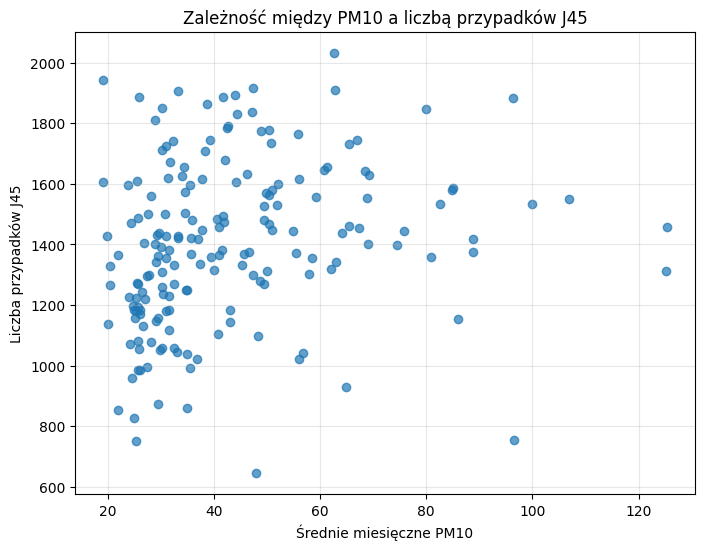

```python
# Wykres punktowy PM10 vs J45
import matplotlib.pyplot as plt

plt.figure(figsize=(8, 6))
plt.scatter(corr_data["PM10"], corr_data["J45"], alpha=0.7)
plt.title("Zależność między PM10 a liczbą przypadków J45")
plt.xlabel("Średnie miesięczne PM10")
plt.ylabel("Liczba przypadków J45")
plt.grid(alpha=0.3)
plt.show()
```

```python
# Korelacja Pearsona
# H0: Nie istnieje istotna liniowa zależność między PM10 a liczbą przypadków J45.
# H1: Istnieje istotna liniowa zależność między PM10 a liczbą przypadków J45.
from scipy.stats import pearsonr

pearson_corr, pearson_p = pearsonr(corr_data["PM10"], corr_data["J45"])

print("Korelacja Pearsona PM10 vs J45")
print("r =", pearson_corr)
print("p-value =", pearson_p)

if pearson_p < 0.05:
    print("Korelacja Pearsona jest istotna statystycznie.")
else:
    print("Brak podstaw do uznania korelacji Pearsona za istotną statystycznie.")
```

```
Korelacja Pearsona PM10 vs J45
r = 0.21854295653456496
p-value = 0.0030376263847116908
Korelacja Pearsona jest istotna statystycznie.
```

```python
# Interpretacja kierunku
if pearson_corr > 0:
    print("Kierunek zależności: dodatni - wraz ze wzrostem PM10 rośnie J45.")
elif pearson_corr < 0:
    print("Kierunek zależności: ujemny - wraz ze wzrostem PM10 maleje J45.")
else:
    print("Brak zależności liniowej.")
```

```
Kierunek zależności: dodatni - wraz ze wzrostem PM10 rośnie J45.
```

```python
# Korelacja Spearmana
# H0: Nie istnieje istotna monotoniczna zależność między PM10 a liczbą przypadków J45.
# H1: Istnieje istotna monotoniczna zależność między PM10 a liczbą przypadków J45.
from scipy.stats import spearmanr

spearman_corr, spearman_p = spearmanr(corr_data["PM10"], corr_data["J45"])

print("Korelacja Spearmana PM10 vs J45")
print("rho =", spearman_corr)
print("p-value =", spearman_p)

if spearman_p < 0.05:
    print("Korelacja Spearmana jest istotna statystycznie.")
else:
    print("Brak podstaw do uznania korelacji Spearmana za istotną statystycznie.")
```

```
Korelacja Spearmana PM10 vs J45
rho = 0.34229368921333236
p-value = 2.2492098866038808e-06
Korelacja Spearmana jest istotna statystycznie.
```

```python
# Pomocnicza interpretacja siły korelacji
def interpretuj_korelacje(r):
    abs_r = abs(r)

    if abs_r < 0.2:
        sila = "bardzo słaba"
    elif abs_r < 0.4:
        sila = "słaba"
    elif abs_r < 0.6:
        sila = "umiarkowana"
    elif abs_r < 0.8:
        sila = "silna"
    else:
        sila = "bardzo silna"

    if r > 0:
        kierunek = "dodatnia"
    elif r < 0:
        kierunek = "ujemna"
    else:
        kierunek = "brak kierunku"

    return sila, kierunek

sila_p, kierunek_p = interpretuj_korelacje(pearson_corr)
sila_s, kierunek_s = interpretuj_korelacje(spearman_corr)

print(f"Pearson: korelacja {kierunek_p}, siła: {sila_p}")
print(f"Spearman: korelacja {kierunek_s}, siła: {sila_s}")
```

```
Pearson: korelacja dodatnia, siła: słaba
Spearman: korelacja dodatnia, siła: słaba
```

```python
# Korelacja osobno dla Gliwic i Tychów
for miasto in corr_data["Miasto"].unique():
    city_data = corr_data[corr_data["Miasto"] == miasto]

    r, p = pearsonr(city_data["PM10"], city_data["J45"])
    rho, p_s = spearmanr(city_data["PM10"], city_data["J45"])

    print(f"\nMiasto: {miasto}")
    print(f"Pearson r = {r:.4f}, p-value = {p:.4f}")
    print(f"Spearman rho = {rho:.4f}, p-value = {p_s:.4f}")
```

```
Miasto: Gliwice
Pearson r = 0.1338, p-value = 0.2138
Spearman rho = 0.1964, p-value = 0.0667

Miasto: Tychy
Pearson r = 0.2387, p-value = 0.0205
Spearman rho = 0.3672, p-value = 0.0003
```

```python
# Regresja liniowa: J45 ~ PM10
import statsmodels.api as sm

X = corr_data["PM10"]
y = corr_data["J45"]

# dodajemy wyraz wolny do modelu
X = sm.add_constant(X)

model = sm.OLS(y, X).fit()

print(model.summary())

# prostsza interpretacja
print("Współczynnik regresji dla PM10:", model.params["PM10"])
print("Wyraz wolny:", model.params["const"])
print("p-value dla PM10:", model.pvalues["PM10"])
print("R-squared:", model.rsquared)

if model.pvalues["PM10"] < 0.05:
    print("PM10 jest istotnym statystycznie predyktorem liczby przypadków J45.")
else:
    print("PM10 nie jest istotnym statystycznie predyktorem liczby przypadków J45.")

print(f"Model wyjaśnia około {model.rsquared * 100:.2f}% zmienności liczby przypadków J45.")
```

```
                            OLS Regression Results
==============================================================================
Dep. Variable:                    J45   R-squared:                       0.048
Model:                            OLS   Adj. R-squared:                  0.042
Method:                 Least Squares   F-statistic:                     9.028
Date:                Mon, 15 Jun 2026   Prob (F-statistic):            0.00304
Time:                        11:43:11   Log-Likelihood:                -1273.1
No. Observations:                 182   AIC:                             2550.
Df Residuals:                     180   BIC:                             2557.
Df Model:                           1
Covariance Type:            nonrobust
==============================================================================
                 coef    std err          t      P>|t|      [0.025      0.975]
------------------------------------------------------------------------------
const       1274.1093     46.670     27.300      0.000    1182.018    1366.200
PM10           2.9379      0.978      3.005      0.003       1.009       4.867
==============================================================================
Omnibus:                        0.469   Durbin-Watson:                   0.891
Prob(Omnibus):                  0.791   Jarque-Bera (JB):                0.326
Skew:                          -0.102   Prob(JB):                        0.849
Kurtosis:                       3.040   Cond. No.                         113.
==============================================================================

Notes:
[1] Standard Errors assume that the covariance matrix of the errors is correctly specified.
Współczynnik regresji dla PM10: 2.9378733974250766
Wyraz wolny: 1274.1093092878832
p-value dla PM10: 0.003037626384711616
R-squared: 0.04776102385086889
PM10 jest istotnym statystycznie predyktorem liczby przypadków J45.
Model wyjaśnia około 4.78% zmienności liczby przypadków J45.
```

### Interpretacja korelacji i regresji

Dla całego zbioru danych współczynnik korelacji Pearsona między PM10 a J45 wyniósł r = 0,219, przy p-value = 0,003. Oznacza to słabą dodatnią zależność liniową, istotną statystycznie na poziomie istotności α = 0,05. Wraz ze wzrostem średniego miesięcznego stężenia PM10 liczba przypadków J45 ma tendencję do wzrostu, jednak siła tej zależności jest niewielka.

Współczynnik korelacji Spearmana wyniósł rho = 0,342, przy p-value < 0,001. Również wskazuje to na dodatnią i istotną statystycznie zależność, ale nadal o słabej sile. Wynik Spearmana jest nieco wyższy niż Pearsona, co może sugerować, że zależność między zmiennymi jest bardziej monotoniczna niż idealnie liniowa.

Analiza osobno dla miast pokazała, że w Gliwicach korelacje nie były istotne statystycznie, natomiast w Tychach zależność między PM10 a J45 była istotna. Może to oznaczać, że zależność między zanieczyszczeniem powietrza a liczbą przypadków J45 nie jest taka sama w obu miastach.

Model regresji liniowej dla całego zbioru danych wykazał, że PM10 jest istotnym statystycznie predyktorem liczby przypadków J45. Wartość R² wyniosła około 0,048, co oznacza, że model wyjaśnia około 4,8% zmienności liczby przypadków J45. Oznacza to, że samo PM10 nie wystarcza do dokładnego przewidywania liczby przypadków astmy, ale może być jednym z czynników powiązanych z jej występowaniem.

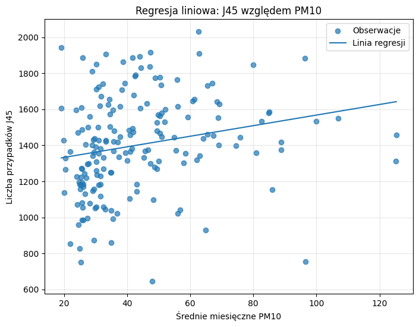

```python
# Wykres punktowy z linią regresji
import numpy as np

plt.figure(figsize=(8, 6))

plt.scatter(corr_data["PM10"], corr_data["J45"], alpha=0.7, label="Obserwacje")

# linia regresji
x_values = np.linspace(corr_data["PM10"].min(), corr_data["PM10"].max(), 100)
y_values = model.params["const"] + model.params["PM10"] * x_values

plt.plot(x_values, y_values, label="Linia regresji")

plt.title("Regresja liniowa: J45 względem PM10")
plt.xlabel("Średnie miesięczne PM10")
plt.ylabel("Liczba przypadków J45")
plt.legend()
plt.grid(alpha=0.3)
plt.show()
```

```python
# Regresja osobno dla miast
for miasto in corr_data["Miasto"].unique():
    city_data = corr_data[corr_data["Miasto"] == miasto]

    X_city = sm.add_constant(city_data["PM10"])
    y_city = city_data["J45"]

    model_city = sm.OLS(y_city, X_city).fit()

    print(f"\nRegresja dla miasta: {miasto}")
    print("Współczynnik PM10:", model_city.params["PM10"])
    print("p-value PM10:", model_city.pvalues["PM10"])
    print("R-squared:", model_city.rsquared)
```

```
Regresja dla miasta: Gliwice
Współczynnik PM10: 1.474420656914742
p-value PM10: 0.2138138457425919
R-squared: 0.01791217596657313

Regresja dla miasta: Tychy
Współczynnik PM10: 2.6325515502290413
p-value PM10: 0.020502252506849027
R-squared: 0.0569829755491974
```

# IV. Analiza szeregów czasowych

W analizie szeregów czasowych wykorzystano miesięczne wartości PM10 dla miasta Gliwice. Wybrano PM10, ponieważ zanieczyszczenie powietrza ma naturalny charakter czasowy i sezonowy — wartości mogą różnić się między miesiącami, szczególnie w sezonie grzewczym. Dane miesięczne obejmują lata 2007–2014, czyli 96 obserwacji.

```python
# Przygotowanie danych

import pandas as pd
import numpy as np
import matplotlib.pyplot as plt

selected_city = "Gliwice"
selected_variable = "PM10"

ts_data = df_all[df_all["Miasto"] == selected_city].copy()

# upewniamy się, że data istnieje i jest poprawna
ts_data["Data"] = pd.to_datetime(
    ts_data["Rok"].astype(str) + "-" + ts_data["Miesiac"].astype(str) + "-01"
)

ts_data[selected_variable] = pd.to_numeric(ts_data[selected_variable], errors="coerce")

# ustawiamy datę jako indeks
ts_data = ts_data.sort_values("Data")
ts = ts_data.set_index("Data")[selected_variable]

# wymuszamy miesięczną częstotliwość
ts = ts.asfreq("MS")

print("Liczba obserwacji:", len(ts))
print("Liczba braków:", ts.isna().sum())

display(ts.head(12))
```

```
Liczba obserwacji: 96
Liczba braków: 8
```

```
Data
2007-01-01    19.187994
2007-02-01    38.279270
2007-03-01    62.601449
2007-04-01    44.388164
2007-05-01    28.912873
2007-06-01    30.937500
2007-07-01    28.869331
2007-08-01    30.387915
2007-09-01    31.425928
2007-10-01    42.401590
2007-11-01    41.806824
2007-12-01    26.065217
Freq: MS, Name: PM10, dtype: float64
```

```python
# Uzupełnienie braków interpolacją liniową

ts_filled = ts.interpolate(method="linear")

print("Liczba braków przed interpolacją:", ts.isna().sum())
print("Liczba braków po interpolacji:", ts_filled.isna().sum())

display(ts_filled.head(12))
```

```
Liczba braków przed interpolacją: 8
Liczba braków po interpolacji: 0
```

```
Data
2007-01-01    19.187994
2007-02-01    38.279270
2007-03-01    62.601449
2007-04-01    44.388164
2007-05-01    28.912873
2007-06-01    30.937500
2007-07-01    28.869331
2007-08-01    30.387915
2007-09-01    31.425928
2007-10-01    42.401590
2007-11-01    41.806824
2007-12-01    26.065217
Freq: MS, Name: PM10, dtype: float64
```

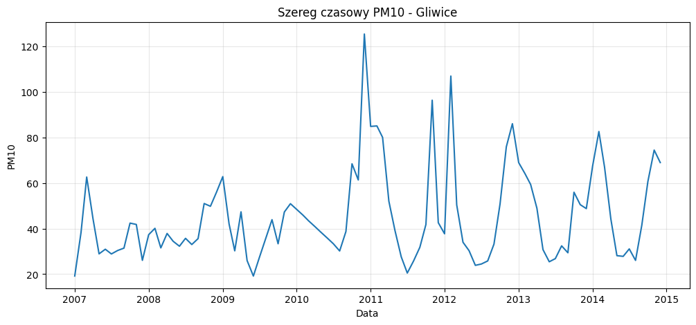

```python
# Wykres szeregu czasowego PM10
plt.figure(figsize=(12, 5))
plt.plot(ts_filled.index, ts_filled.values)
plt.title(f"Szereg czasowy {selected_variable} - {selected_city}")
plt.xlabel("Data")
plt.ylabel(selected_variable)
plt.grid(alpha=0.3)
plt.show()
```

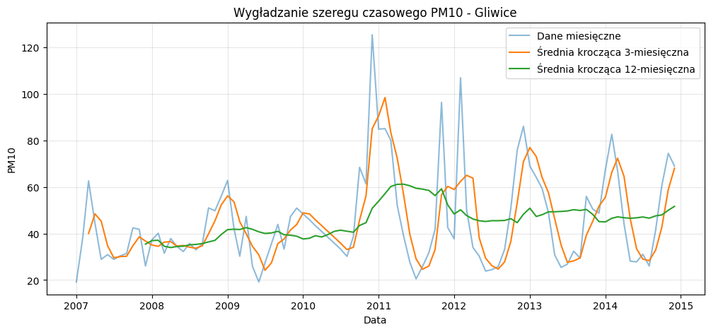

```python
# Trend i wygładzanie średnią kroczącą ( 3 i 12 miesięcy)

rolling_3 = ts_filled.rolling(window=3).mean()
rolling_12 = ts_filled.rolling(window=12).mean()

plt.figure(figsize=(12, 5))
plt.plot(ts_filled.index, ts_filled.values, label="Dane miesięczne", alpha=0.5)
plt.plot(rolling_3.index, rolling_3.values, label="Średnia krocząca 3-miesięczna")
plt.plot(rolling_12.index, rolling_12.values, label="Średnia krocząca 12-miesięczna")
plt.title(f"Wygładzanie szeregu czasowego {selected_variable} - {selected_city}")
plt.xlabel("Data")
plt.ylabel(selected_variable)
plt.legend()
plt.grid(alpha=0.3)
plt.show()
```

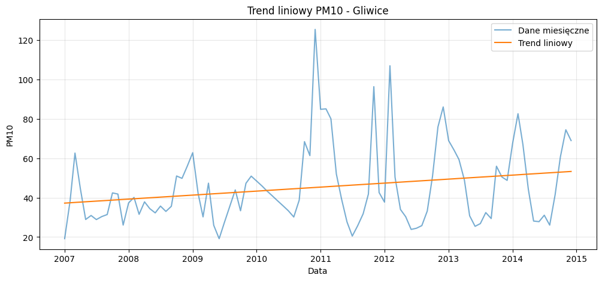

```
Współczynnik kierunkowy trendu: 0.16902135733185028
Wyraz wolny: 37.22014504049517
Trend jest rosnący.
```

```python
# Trend liniowy

time_index = np.arange(len(ts_filled))
trend_coefficients = np.polyfit(time_index, ts_filled.values, 1)
trend_line = np.polyval(trend_coefficients, time_index)

plt.figure(figsize=(12, 5))
plt.plot(ts_filled.index, ts_filled.values, label="Dane miesięczne", alpha=0.6)
plt.plot(ts_filled.index, trend_line, label="Trend liniowy")
plt.title(f"Trend liniowy {selected_variable} - {selected_city}")
plt.xlabel("Data")
plt.ylabel(selected_variable)
plt.legend()
plt.grid(alpha=0.3)
plt.show()

print("Współczynnik kierunkowy trendu:", trend_coefficients[0])
print("Wyraz wolny:", trend_coefficients[1])

if trend_coefficients[0] > 0:
    print("Trend jest rosnący.")
elif trend_coefficients[0] < 0:
    print("Trend jest malejący.")
else:
    print("Brak trendu liniowego.")
```

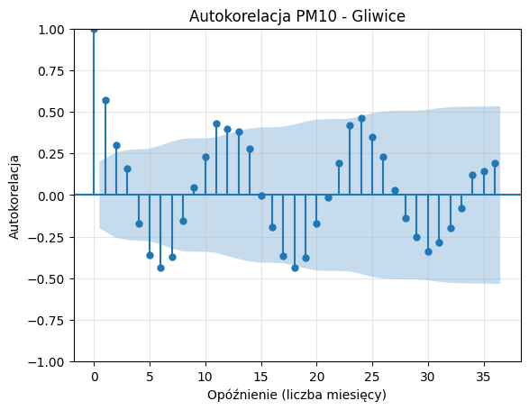

```python
# Autokorelacja szeregu czasowego
from statsmodels.graphics.tsaplots import plot_acf

plt.figure(figsize=(10, 5))
plot_acf(ts_filled, lags=36)
plt.title(f"Autokorelacja {selected_variable} - {selected_city}")
plt.xlabel("Opóźnienie (liczba miesięcy)")
plt.ylabel("Autokorelacja")
plt.grid(alpha=0.3)
plt.show()
```

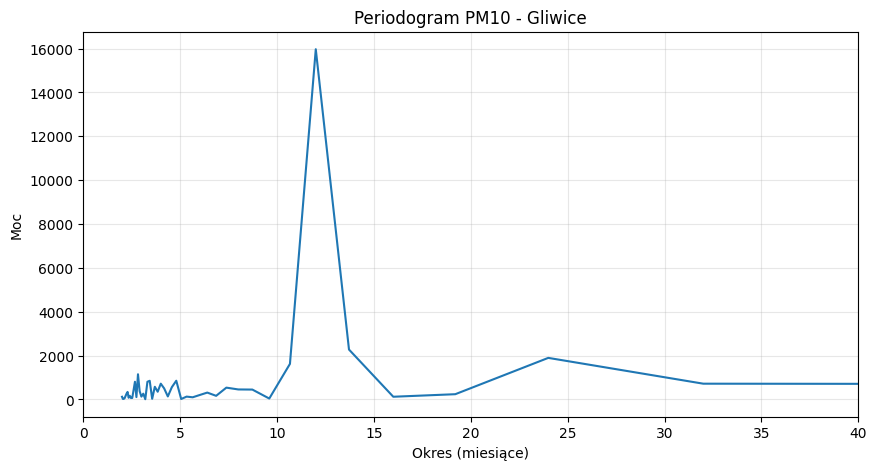

|  | Okres_miesiace | Moc |
| --- | --- | --- |
| 7 | 12.000000 | 15972.082727 |
| 0 | 96.000000 | 2360.244602 |
| 6 | 13.714286 | 2275.502476 |
| 3 | 24.000000 | 1894.945113 |
| 8 | 10.666667 | 1621.111197 |
| 33 | 2.823529 | 1148.198075 |
| 19 | 4.800000 | 853.387418 |
| 27 | 3.428571 | 851.076291 |
| 35 | 2.666667 | 806.793536 |
| 28 | 3.310345 | 805.265985 |

```python
# Periodogram
from scipy.signal import periodogram

frequencies, power = periodogram(ts_filled.values)

# usuwamy częstotliwość 0, bo odpowiada składowej stałej
frequencies_nonzero = frequencies[1:]
power_nonzero = power[1:]

periods = 1 / frequencies_nonzero

plt.figure(figsize=(10, 5))
plt.plot(periods, power_nonzero)
plt.xlim(0, 40)
plt.title(f"Periodogram {selected_variable} - {selected_city}")
plt.xlabel("Okres (miesiące)")
plt.ylabel("Moc")
plt.grid(alpha=0.3)
plt.show()

# Najsilniejsze okresy
periodogram_results = pd.DataFrame({
    "Okres_miesiace": periods,
    "Moc": power_nonzero
}).sort_values("Moc", ascending=False)

display(periodogram_results.head(10))
```

| Miesiac | Średnia miesięczna | Współczynnik sezonowości |
| --- | --- | --- |
| 1 | 53.324217 | 1.178471 |
| 2 | 63.116292 | 1.394876 |
| 3 | 53.052334 | 1.172462 |
| 4 | 43.705378 | 0.965893 |
| 5 | 32.007996 | 0.707380 |
| 6 | 27.869778 | 0.615925 |
| 7 | 28.523798 | 0.630379 |
| 8 | 29.910510 | 0.661025 |
| 9 | 35.691429 | 0.788784 |
| 10 | 50.549176 | 1.117142 |
| 11 | 62.158738 | 1.373714 |
| 12 | 63.074269 | 1.393948 |

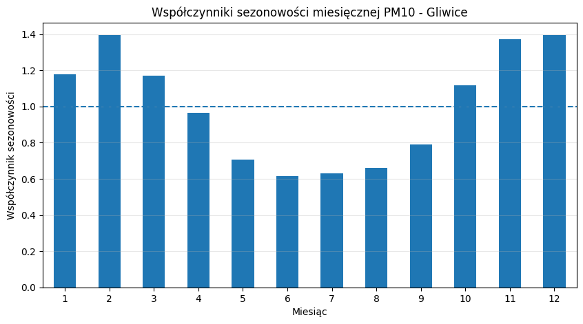

```python
# Współczynniki sezonowości miesięcznej

seasonality_df = ts_filled.reset_index()
seasonality_df.columns = ["Data", selected_variable]
seasonality_df["Miesiac"] = seasonality_df["Data"].dt.month

monthly_means = seasonality_df.groupby("Miesiac")[selected_variable].mean()
overall_mean = seasonality_df[selected_variable].mean()

seasonality_coefficients = monthly_means / overall_mean

seasonality_table = pd.DataFrame({
    "Średnia miesięczna": monthly_means,
    "Współczynnik sezonowości": seasonality_coefficients
})

display(seasonality_table)

# Wykres współczynników sezonowości
# Interpretacja: współczynnik > 1 oznacza, że dany miesiąc ma średnią wyższą niż ogólna średnia, a współczynnik < 1 oznacza, że dany miesiąc ma średnią niższą niż ogólna średnia.
plt.figure(figsize=(10, 5))
seasonality_coefficients.plot(kind="bar")
plt.axhline(1, linestyle="--")
plt.title(f"Współczynniki sezonowości miesięcznej {selected_variable} - {selected_city}")
plt.xlabel("Miesiąc")
plt.ylabel("Współczynnik sezonowości")
plt.xticks(rotation=0)
plt.grid(axis="y", alpha=0.3)
plt.show()
```

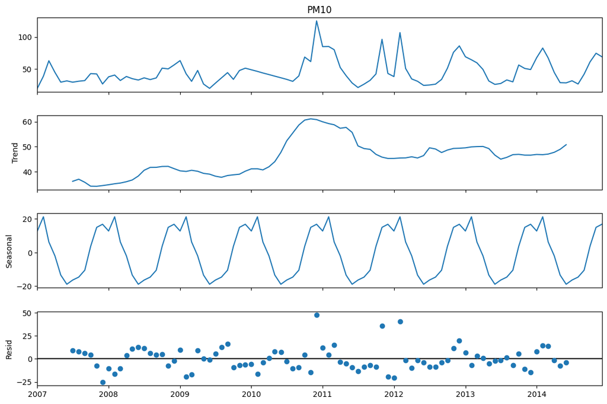

```python
# Dekompozycja szeregu czasowego
from statsmodels.tsa.seasonal import seasonal_decompose

decomposition = seasonal_decompose(
    ts_filled,
    model="additive",
    period=12
)

fig = decomposition.plot()
fig.set_size_inches(12, 8)
plt.show()
```

### Interpretacja analizy szeregów czasowych

Analiza szeregu czasowego została wykonana dla miesięcznych wartości PM10 w Gliwicach. Szereg obejmował 96 miesięcy, z czego 8 obserwacji zawierało braki danych. Braki zostały uzupełnione metodą interpolacji liniowej, aby zachować regularny miesięczny charakter szeregu, wymagany m.in. przy analizie autokorelacji, periodogramu i dekompozycji.

Na wykresie szeregu czasowego widoczne są wyraźne wahania miesięczne wartości PM10. Zastosowano wygładzanie za pomocą średniej kroczącej 3-miesięcznej oraz 12-miesięcznej. Średnia 3-miesięczna redukuje krótkookresowe wahania, natomiast średnia 12-miesięczna lepiej pokazuje ogólny przebieg szeregu w czasie.

Wyznaczony trend liniowy ma dodatni współczynnik kierunkowy równy około 0,169, co oznacza, że w analizowanym okresie występuje lekka tendencja rosnąca miesięcznych wartości PM10 w Gliwicach. Należy jednak traktować ten wynik ostrożnie, ponieważ szereg zawiera silne wahania sezonowe.

Autokorelacja pozwoliła ocenić zależność wartości PM10 od wartości z wcześniejszych miesięcy. W danych miesięcznych szczególnie ważne są opóźnienia 12, 24 i 36 miesięcy, ponieważ mogą wskazywać na powtarzalność roczną.

Periodogram wskazał na najsilniejszy okres równy 12 miesięcy. Oznacza to występowanie sezonowości rocznej, co jest zgodne z charakterem zanieczyszczeń powietrza — wartości PM10 są zwykle wyższe w miesiącach zimowych i niższe w miesiącach letnich.

Współczynniki sezonowości miesięcznej potwierdzają tę zależność. Wartości współczynnika powyżej 1 oznaczają miesiące, w których PM10 jest przeciętnie wyższe od średniej ogólnej, natomiast wartości poniżej 1 oznaczają miesiące o niższym przeciętnym PM10. Najwyższe wartości współczynników występują w miesiącach zimowych, zwłaszcza w lutym, co wskazuje na wzrost zanieczyszczenia w sezonie grzewczym. Niższe wartości pojawiają się w miesiącach cieplejszych, co sugeruje spadek poziomu PM10 poza sezonem grzewczym.

Dekompozycja szeregu czasowego rozdzieliła dane na trend, składową sezonową i resztową. Wyniki dekompozycji potwierdzają obecność sezonowości rocznej oraz zmienności losowej, której nie wyjaśnia sam trend ani regularny wzorzec sezonowy.